# USA Domestic Flights Growth Analysis

Eric Hestekin

3/19/2020

# Recent air travel market downturn

[figure not shown]

- Sharp decrease in passenger volume presents revenue challenges

Source Data: [US domestic flights from 1990 to 2009, US Census Bureau](http://academictorrents.com/details/a2ccf94bbb4af222bf8e69dad60a68a29f310d9a)

# Despite volume drop, operating efficiency is up

[figure not shown]

- With fewer passengers it will be important to manage number of seats offered
- Empty seats eat up profit

# Growing cities are a good bet for successful expansion

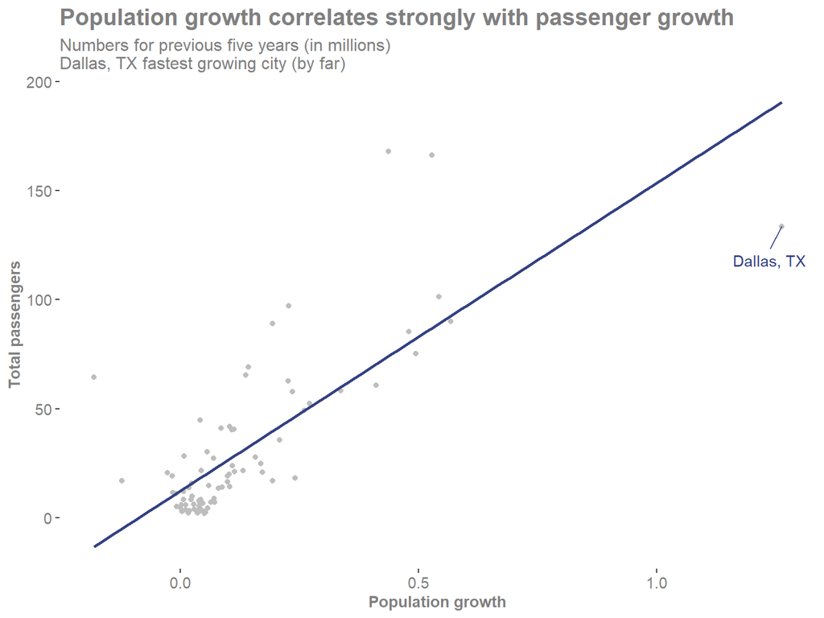

- Despite massive population growth in previous five years, Dallas did not have growth in passenger volume

# High load factor locations provide growth opportunity too

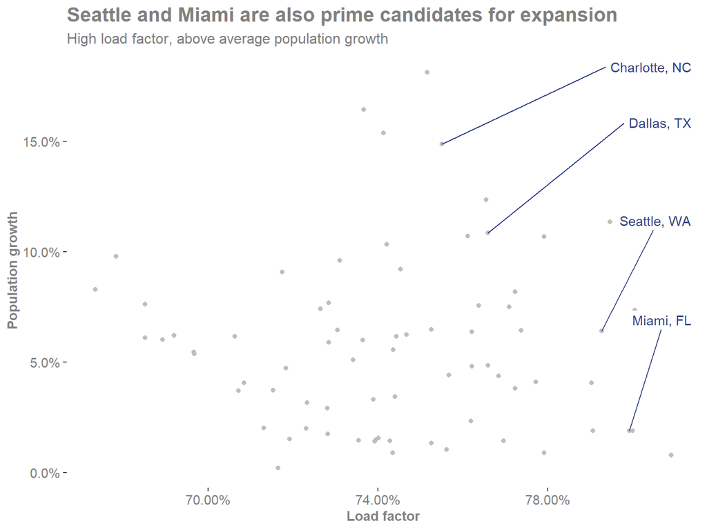

- Above average load factor implies more seats could be offered profitably.
- Combined with positive population growth makes these cities the best bet

# Charlotte should be priority #1 for further growth

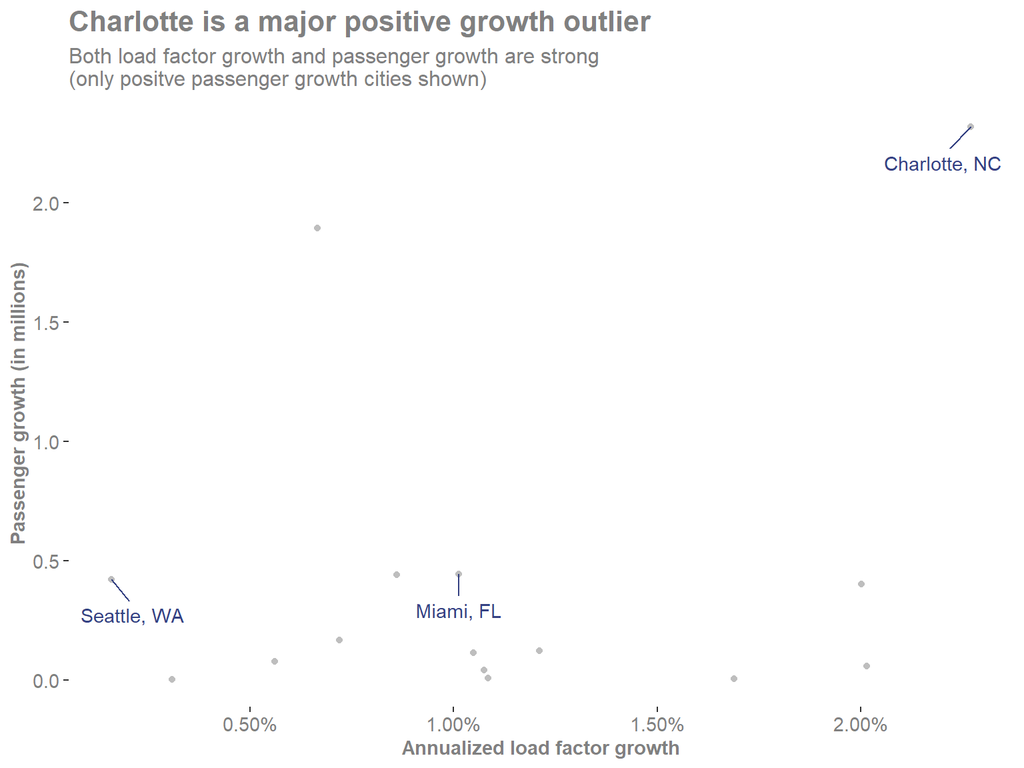

# Conclusion

- Decreasing passenger volumes make efficiency improvements critical
- Dallas, TX is the country’s fastest growing city by population, but has not yet had more seats offered to take advantage of larger population
- Seattle and Miami are good candidates for growth due to:
  - Growing population
  - Increasing passenger numbers despite wider industry downturn
  - High load factor lowers risk
- Charlotte has the most impressive recent growth and should remain a priority for further growth

For comments or questions:  
Eric Hestekin  
ehestekin@seattleu.edu